# Data Science Capstone Project: Milestone Report

Nick Plummer

16/10/2018

# Introduction

This is the first milestone report for the [Coursea Data Science Specialisation](https://www.coursera.org/specializations/jhu-data-science) Capstone Project. It addresses the process of extracting data from the [Heliohost Corpora](http://www.corpora.heliohost.org), cleaning this ready for data mining, and the process of text mining into n-grams to prepare for future work predicting text.

### System setup

```r
library(NLP)          # NLP infrastructure
library(tm)           # Text mining
library(rJava)        # R-Java interface
library(RWeka)        # Tokeniser - create unigrams, bigrams, trigrams
library(ggplot2)      # Visualisation
library(wordcloud)    # Word clouds
library(RColorBrewer) # Palattes
library(googleVis)    # Google charts
```

Note I (and others) have experienced issues on Mac using `rJava` - [see this link](https://zhiyzuo.github.io/installation-rJava/) if getting “unable to load shared object” errors - and `pandoc` breaking with `googleVis` - solution is to install update `pandoc` via `Homebrew`.

# Data Processing

```r
# Download the complete dataset
fileURL <- "http://d396qusza40orc.cloudfront.net/dsscapstone/dataset/Coursera-SwiftKey.zip"
download.file(fileURL, destfile = "Dataset.zip", method = "curl")
unlink(fileURL)
unzip("Dataset.zip")

# Load original US English datasets
blogs <- readLines("./final/en_US/en_US.blogs.txt", encoding = "UTF-8", skipNul=TRUE)
news <- readLines("./final/en_US/en_US.news.txt", encoding = "UTF-8", skipNul=TRUE)
twitter <- readLines("./final/en_US/en_US.twitter.txt", encoding = "UTF-8", skipNul=TRUE)
```

### Aggregate data sample

```r
set.seed(69)
sample_size = 5000

sampleTwitter <- twitter[sample(1:length(twitter),sample_size)]
sampleNews <- news[sample(1:length(news),sample_size)]
sampleBlogs <- blogs[sample(1:length(blogs),sample_size)]

textSample <- c(sampleTwitter,sampleNews,sampleBlogs)
writeLines(textSample, "./milestone/textSample.txt")
rm(sampleTwitter, sampleNews, sampleBlogs)
```

# Summary Statistics

Summary statistics were calculated as below:

```r
# Filesize
blogsFile <- file.info("./final/en_US/en_US.blogs.txt")$size / 1024.0 / 1024.0
newsFile <- file.info("./final/en_US/en_US.news.txt")$size / 1024.0 / 1024.0
twitterFile <- file.info("./final/en_US/en_US.twitter.txt")$size / 1024.0 / 1024.0
sampleFile <- file.info("./milestone/textSample.txt")$size / 1024.0 / 1024.0

# Length (lines)
blogsLength <- length(blogs)
newsLength <- length(news)
twitterLength <- length(twitter)
sampleLength <- length(textSample)

# Total words
blogsWords <- sum(sapply(gregexpr("\\S+", blogs), length))
newsWords <- sum(sapply(gregexpr("\\S+", news), length))
twitterWords <- sum(sapply(gregexpr("\\S+", twitter), length))
sampleWords <- sum(sapply(gregexpr("\\S+", textSample), length))

# Build summary table
fileSummary <- data.frame(
  fileName = c("Blogs","News","Twitter", "Sample"),
  fileSize = c(round(blogsFile, digits = 1),
               round(newsFile, digits = 1),
               round(twitterFile, digits = 1),
               round(sampleFile, digits = 1)),
  lineCount = c(blogsLength, newsLength, twitterLength, sampleLength),
  wordCount = c(blogsWords, newsWords, twitterWords, sampleLength)
  )
colnames(fileSummary) <- c("File", "Size /Mb", "Lines", "Words")

# Tidy up
rm(blogsFile, blogsLength, blogsWords, newsFile, newsLength, newsWords, twitterFile, twitterLength, twitterWords, sampleFile, sampleLength, sampleWords)
saveRDS(fileSummary, file = "./milestone/fileSummary.Rda")
```

These summaries can be displayed as a table, and as a word cloud usually of the aggregated sample file to provide an overview of word frequencies.

| File | Size /Mb | Lines | Words |
| --- | --- | --- | --- |
| Blogs | 200.4 | 899288 | 37334147 |
| News | 196.3 | 1010242 | 34372530 |
| Twitter | 159.4 | 2360148 | 30373603 |
| Sample | 2.4 | 15000 | 15000 |

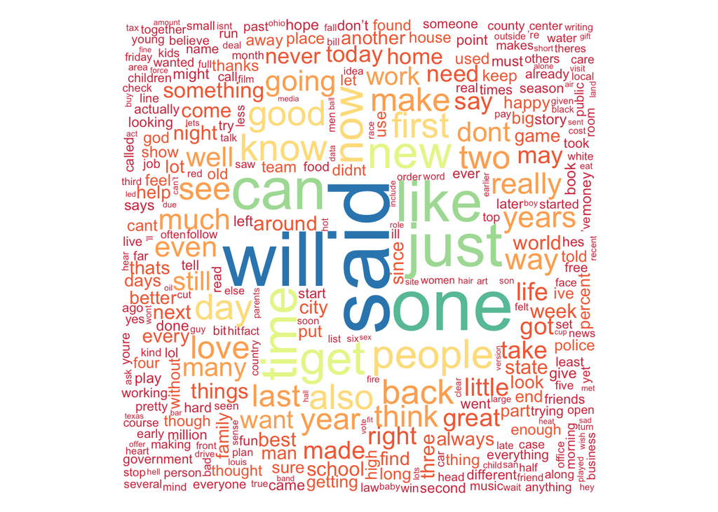

```r
TDM <- TermDocumentMatrix(finalCorpus)
wCloud <- as.matrix(TDM)
v <- sort(rowSums(wCloud),decreasing=TRUE)
d <- data.frame(word = names(v),freq=v)
wordcloud(d$word,d$freq,
  c(5,.3),50,
  random.order=FALSE,
  colors=brewer.pal(8, "Spectral"))
```

# Building A Clean Text Corpus

Sample data was cleaned using `tm` to create a clean text corpus for subsequent processing using the following workflow:

1. Convert to all lower case
2. Remove punctuation and whitespace
3. Discard numbers and urls
4. Erase all stop and [profanity](http://www.cs.cmu.edu/~biglou/resources/) words

```r
textSampleFile <- file("./milestone/textSample.txt")
textSample <- readLines(textSampleFile)
close(textSampleFile)
cleanSample <- VCorpus(VectorSource(textSample))

# Convert all to lower case
cleanSample <- tm_map(cleanSample, content_transformer(tolower), lazy=TRUE)

# Remove puctuation and whitespace
cleanSample <- tm_map(cleanSample, content_transformer(removePunctuation), preserve_intra_word_dashes=TRUE)
cleanSample <- tm_map(cleanSample, stripWhitespace)

# Discard numbers and URLs
cleanSample <- tm_map(cleanSample, content_transformer(removeNumbers))
removeURL <- function(x) gsub("http[[:alnum:]]*", "", x)
cleanSample <- tm_map(cleanSample, content_transformer(removeURL))

# Remove stop words and profanity
cleanSample <- tm_map(cleanSample, removeWords, stopwords("english"))
profanityWords <- read.table("./milestone/profanityWords.txt", header = FALSE)
cleanSample <- tm_map(cleanSample, removeWords, profanityWords)

# Saving the final corpus
saveRDS(cleanSample, file = "./milestone/finalCorpus.Rds")
finalCorpus <- readRDS("./milestone/finalCorpus.Rds")
finalCorpusDF <- data.frame(text = unlist(sapply(finalCorpus, `[`, "content")), stringsAsFactors = FALSE)
```

# N-gram tokenization

The next step breaks the sentences down into “n-grams” via the process of tokenization. In Natural Language Processing (NLP) a n-gram is a contiguous sequence of n items from a given sequence of text or speech. Unigrams or 1-grams are single words, bigrams or 2-grams two word combinations, trigrams or 3-grams three word combinations, and so on.

We used the tokeniser method from `RWeka` in the following generic function to extract n-grams from the cleaned sample text corpus:

```r
ngramTokenizer <- function(theCorpus, ngramCount) {
  ngramFunction <- NGramTokenizer(theCorpus,
    Weka_control(min = ngramCount, max = ngramCount,
    delimiters = " \\r\\n\\t.,;:\"()?!"))
  ngramFunction <- data.frame(table(ngramFunction))
  ngramFunction <- ngramFunction[order(ngramFunction$Freq,
                   decreasing = TRUE),][1:10,]
  colnames(ngramFunction) <- c("String","Count")
  ngramFunction
}

# Application to specific n-grams
unigram <- ngramTokenizer(finalCorpusDF, 1)
saveRDS(unigram, file = "./milestone/unigram.Rds")
bigram <- ngramTokenizer(finalCorpusDF, 2)
saveRDS(bigram, file = "./milestone/bigram.Rds")
trigram <- ngramTokenizer(finalCorpusDF, 3)
saveRDS(trigram, file = "./milestone/trigram.Rds")
```

### Most common n-grams in sample data set

```r
# 1-grams
unigram <- readRDS("./unigram.RDS")
unigramPlot <- gvisColumnChart(unigram, "String", "Count", options=list(legend="none"))
print(unigramPlot, "chart")
```

[output not shown]

```r
# 2-grams
bigram <- readRDS("./bigram.RDS")
bigramPlot <- gvisColumnChart(bigram, "String", "Count", options=list(legend="none"))
print(bigramPlot, "chart")
```

[output not shown]

```r
# 3-grams
trigram <- readRDS("./trigram.RDS")
trigramPlot <- gvisColumnChart(trigram, "String", "Count", options=list(legend="none"))
print(trigramPlot, "chart")
```

[output not shown]

# Next steps

It’s clear that loading and handling the dataset costs a lot of time, due to its size. The use of a sample dataset was therefore essential to allow text mining and tokenization over a reasonable timescale, however this workaround decreases the accuracy for and subsequent predictions based on these.

Removing all stopwords from the corpus is recommended, however stopwords (and, to an extent, profanity) are a fundamental part of languages. Therefore, consideration should be given to include these stop words in the prediction application again, and whether replacement of profanity with contextually appropriate non-curse words may improve accurary of what become otherwise disjointed sentences..

The next phase of the capstone project will be to create a prediction application based on this handling of n-grams. This will require speedier and lighter processing of larger datasets to enable a faster prediction algorithm to be designed. Increasing the value of n for n-gram tokenization will improve the prediction accuracy at the expense of slowing the algorithm.